# Assignment_4

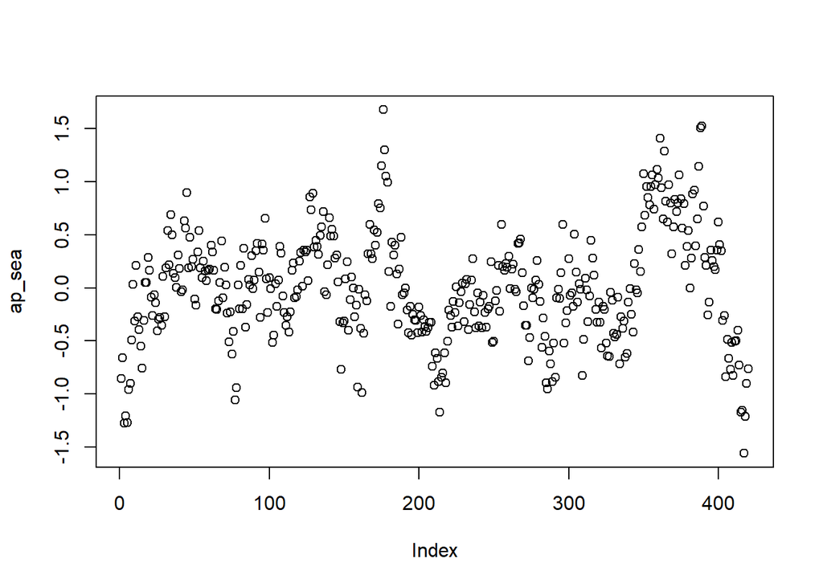

```r
ap_sea = period$residuals
plot(ap_sea)
```

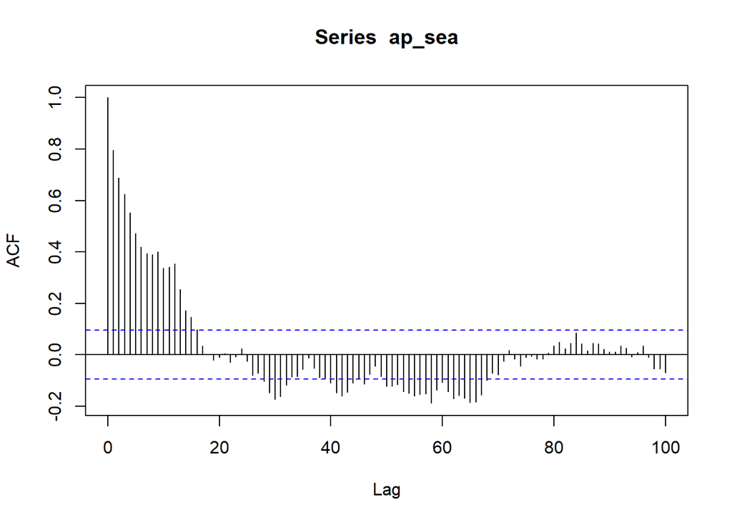

```r
acf(ap_sea, lag.max = 100)
```

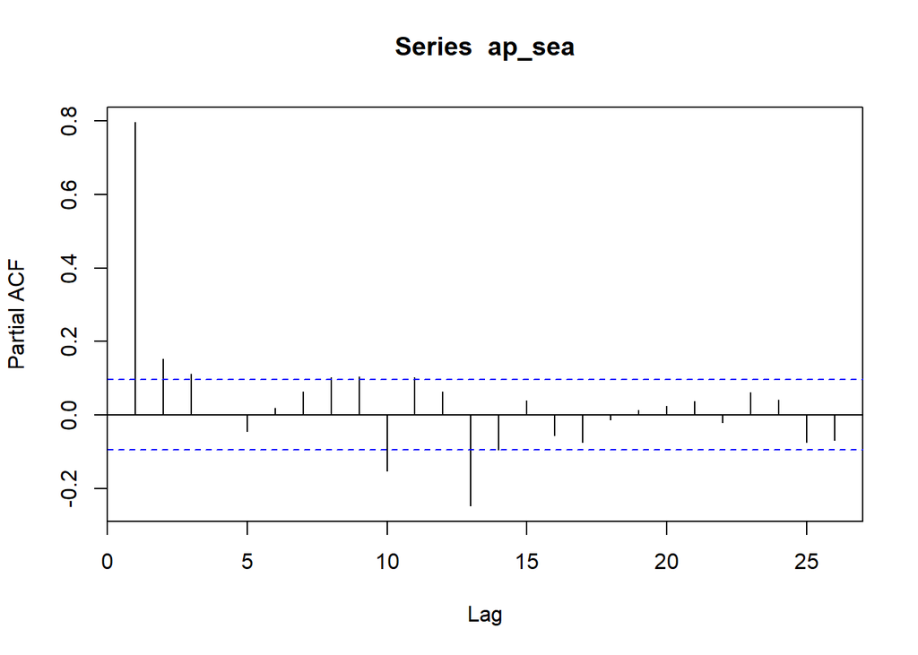

```r
pacf(ap_sea)
```

Observing the PACF of the residual obtained after fitting the trend and seasonality we can vaguely conclude the process is AR(13)

```r
armod = arima(ap_sea, c(13,0,0))
armo  = ar(ap_sea, aic = TRUE, order.max = 13)
print(armod)
```

```
##
## Call:
## arima(x = ap_sea, order = c(13, 0, 0))
##
## Coefficients:
##          ar1     ar2     ar3     ar4      ar5      ar6     ar7     ar8
##       0.6739  0.0912  0.0508  0.0739  -0.0653  -0.0222  0.0101  0.0069
## s.e.  0.0470  0.0564  0.0565  0.0559   0.0555   0.0553  0.0553  0.0554
##          ar9     ar10    ar11    ar12     ar13  intercept
##       0.1933  -0.1892  0.0809  0.2292  -0.2558    -0.0390
## s.e.  0.0555   0.0562  0.0572  0.0572   0.0483     0.1127
##
## sigma^2 estimated as 0.08032:  log likelihood = -67.72,  aic = 165.44
```

```r
print(armo)
```

```
##
## Call:
## ar(x = ap_sea, aic = TRUE, order.max = 13)
##
## Coefficients:
##       1        2        3        4        5        6        7        8
##  0.6806   0.1012   0.0454   0.0629  -0.0741  -0.0272   0.0013   0.0147
##       9       10       11       12       13
##  0.1890  -0.1978   0.0803   0.2278  -0.2474
##
## Order selected 13  sigma^2 estimated as  0.08596
```

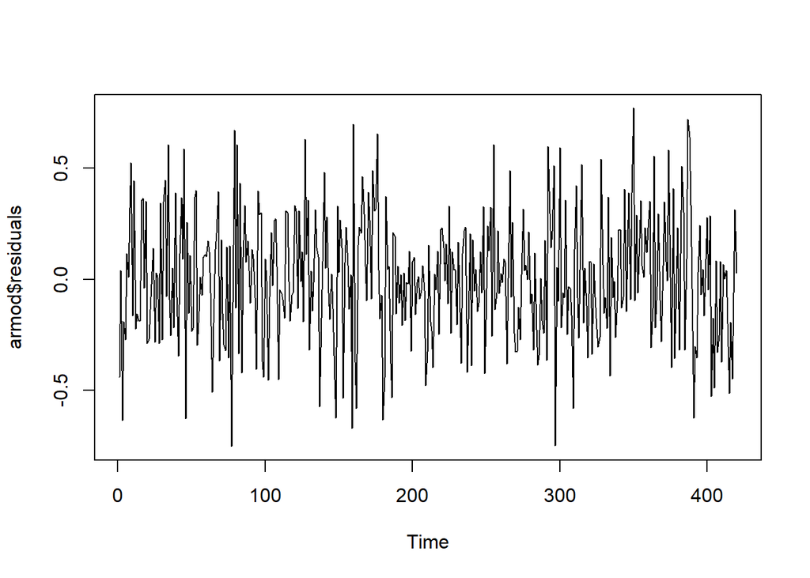

```r
plot(armod$residuals)
```

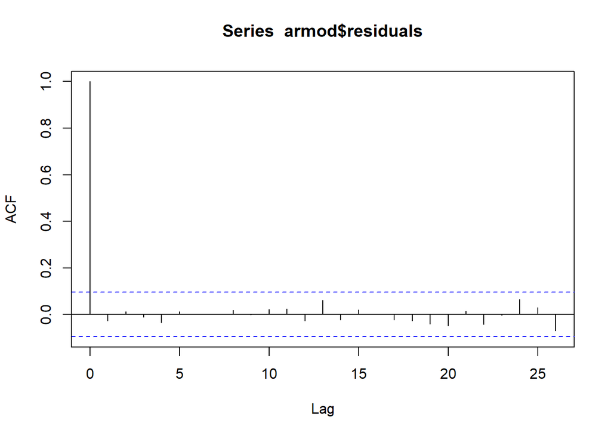

```r
acf(armod$residuals)
```

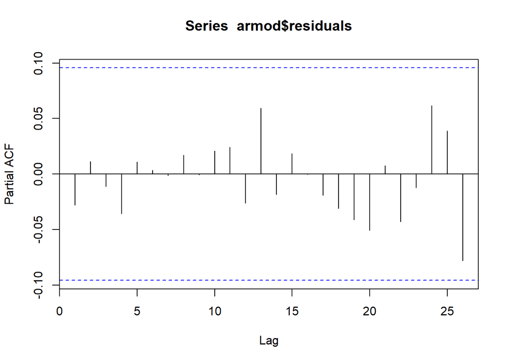

```r
pacf(armod$residuals)
```

Above we can see that from both method (‘arima’ and ‘ar’ function) AR(13) model has been chosen comparing the AIC’s of all the AR model upto order 13.

Also, we can clearly see that the AR(13) model overfits the data but the residuals obtained after fitting the AR(13) model satisfies the white noise characteristics.

Hence, comprising the overfitting test we chose AR(13) model to fit the stationary process of the given co2 data.

```r
set.seed(21)
t = 1:468
test = co2[421:468]
#vk = arima.sim(468, model = list(ar = c(-0.6379, -0.0912, -0.0508, -0.0739, 0.6653,0.0222,-0.0101,-0.0069, -0.1933, 0.1892, -0.0809, -0.2292, 0.2558), ma = c(0,0,0)))

#Error : model not stationary

seasonal = 2.159*sin(2*pi*t/12) - 1.727*cos(2*pi*t/12) - 0.008085*sin(2*pi*t/6) + 0.7619*cos(2*pi*t/6)

#xk = 334.251 + 263.306*t + 29.209*t^2 - 8.685*t^3 + vk + seasonal

#plot(xk)
```

### Q.4 ACVF from PSD

The p.s.d of a stationary process is given by

$$\gamma_{xx}(f) = \frac{1.44}{1.16 - 0.8cos(2\pi f)}$$

$$\gamma_{xx}(\omega) = \frac{1.44}{2\pi}\frac{1}{1.16 - 0.8cos(\omega)}$$
$$|H(e^{-j \omega l})|^2 = \frac{1}{1.16 - 0.8cos(\omega)}$$
We know that,

$$|H(e^{-j \omega l})|^2 = H(q)H(q^{-1})$$
Therefore factorization gives,

$$H(q^{-1}) = \frac{1}{1-0.4q^{-1}}$$
We can conclude that,

It is an AR(1) process $d_1 = 0.4$ and $\sigma_e^2 = 1.44$

$$\sigma[0] = \frac{\sigma^2_e}{1 - d_1^2}$$
Therefore, $\sigma[0] = 1.7143$

$$\sigma[1] = (-d_1)\sigma[0] \Rightarrow \sigma[1] = 0.6857$$
Similarly,

$\sigma[2] = 0.2743$ $\sigma[3] = 0.1097$ $\sigma[4] = 0.0438$  
$\sigma[5] = 0.0175$

Using the inverse Fourier transform in R

```r
f  = seq(from = -0.5, to = 0.5, by = 0.01)
psd = 1.44/(1.16 - 0.8*cos(2*pi*f))
invft = abs(fft(psd , inverse = TRUE))/length(psd)
invft[1:5]
```

```
## [1] 1.70458679 0.68359278 0.27712131 0.11133245 0.04523069
```

### Q.4 Power spectral density estimation

Simulating series

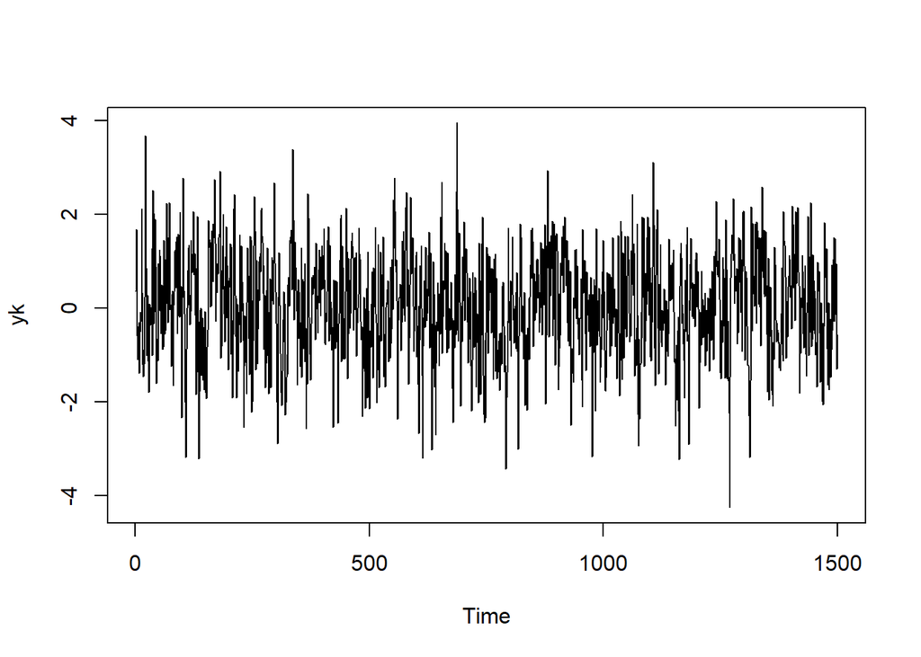

```r
#Simulating series

set.seed(323)
yk = arima.sim(model = list(ar = c(0,0.25), ma = 0.45), 1500)

plot(yk)
```

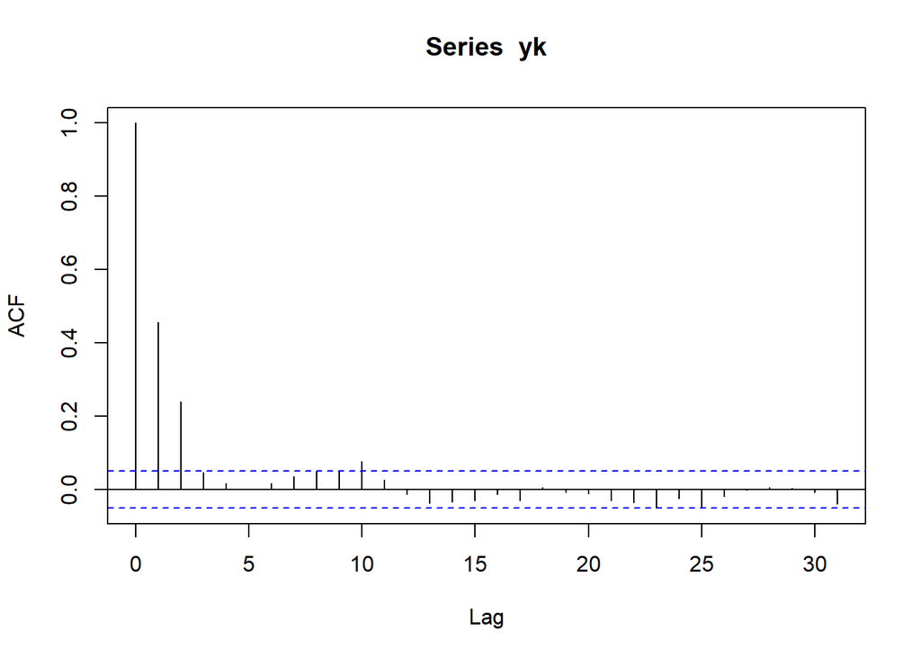

```r
acf(yk)
```

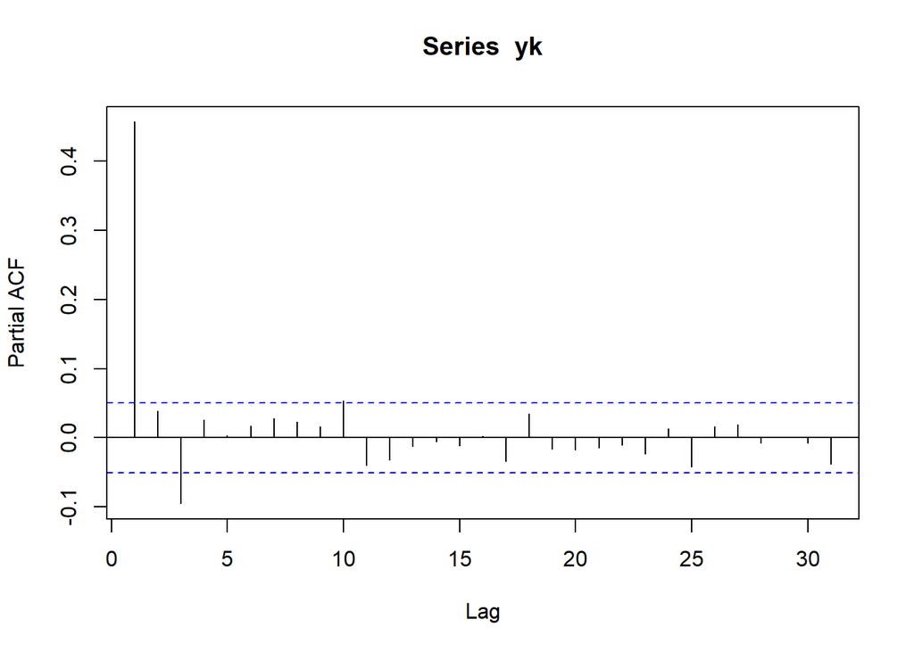

```r
pacf(yk)
```

1. Estimating the ACVF and using W-K theorem

From the Weiner-Khinchin Theorem,
$$\gamma_{vv}(\omega) = \frac{1}{2\pi}\sum_{l = -\infty}^{\infty} \sigma[l]e^{-j\omega l}$$
$$\gamma_{vv}(\omega) = \frac{1}{2\pi}\left(\sigma[0] + 2\sum_{l=0}^{\infty} \sigma[l]cos(\omega l)\right)$$

Usually, we do not have estimates of the ACVF at large lags, However, the ACVF of a stationary time series dies down after few lags. Therefore we can truncate the above expression to the first few lags.

$$\gamma_{vv}(\omega) = \frac{1}{2\pi}\left(\sigma[0] + 2\sum_{l=0}^{l_{max}} \sigma[l]cos(\omega l)\right)$$

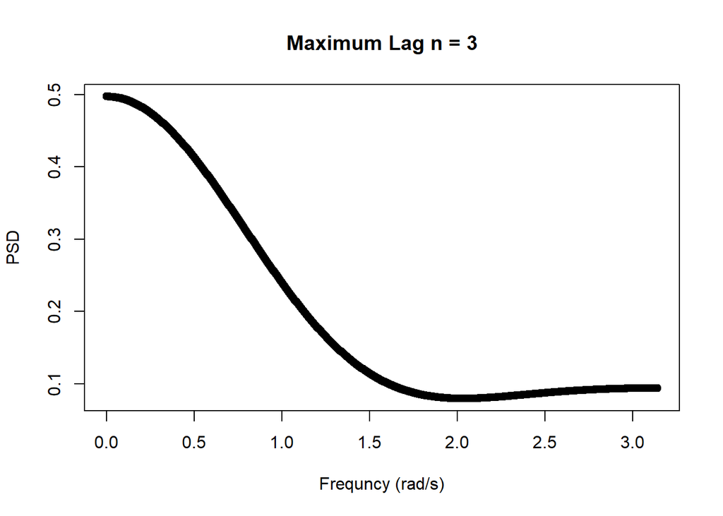

```r
#PSD from Weiner-Khinchin

psd_acf = function(w, acvf, lag_max){

  k = 1:lag_max
  psd_ = (acvf[1] + 2*sum(acvf[-1]*cos(w*k)))/(2*pi)
  psd_
}

w = seq(0,pi,length = 1000)
lag_max = c(3,10,20,40)
wk_gamma = matrix(nrow = 1000, ncol = 4)

for (i in seq_along(lag_max)) {
  acvf = acf(yk, lag_max[i], type = "covariance", plot = FALSE)
  wk_gamma[,i] = sapply(w, psd_acf, acvf$acf, lag_max[i])


}
plot( w, wk_gamma[,1], main = "Maximum Lag n = 3", xlab = "Frequncy (rad/s)", ylab = "PSD")
```

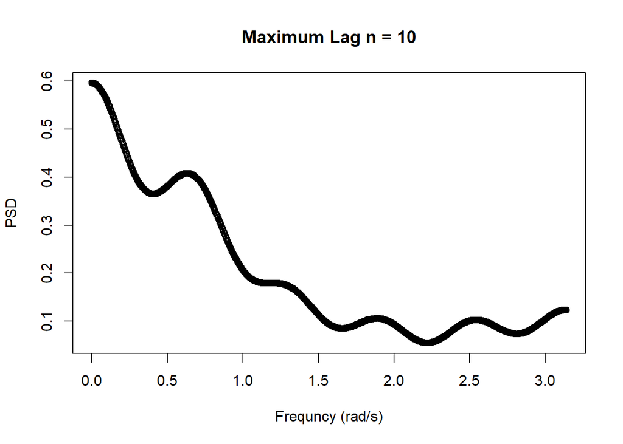

```r
plot( w, wk_gamma[,2], main = "Maximum Lag n = 10",xlab = "Frequncy (rad/s)", ylab = "PSD")
```

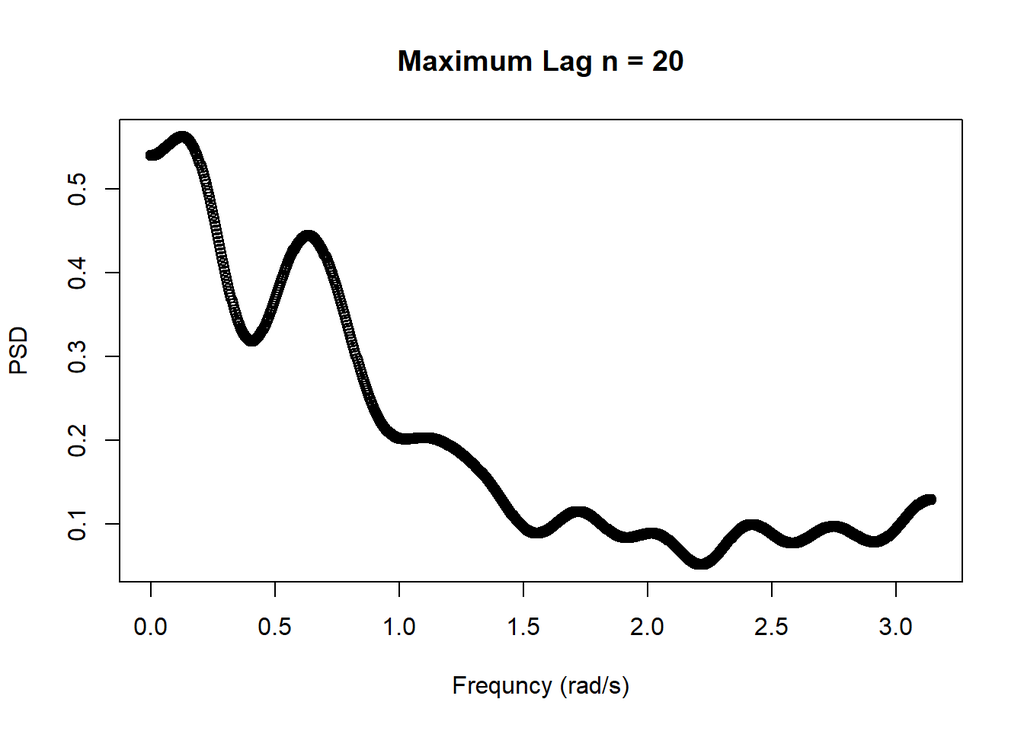

```r
plot( w, wk_gamma[,3], main = "Maximum Lag n = 20",xlab = "Frequncy (rad/s)", ylab = "PSD")
```

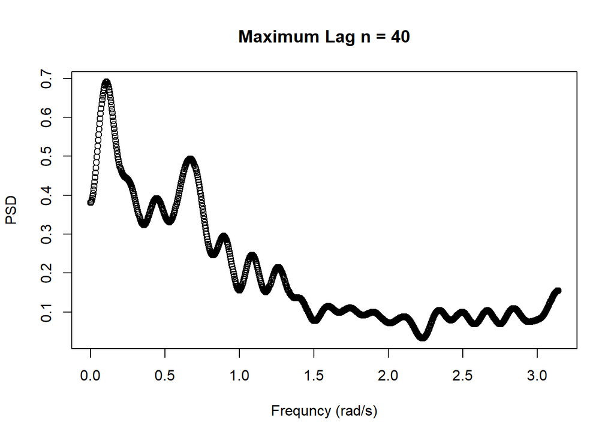

```r
plot( w, wk_gamma[,4], main = "Maximum Lag n = 40",xlab = "Frequncy (rad/s)", ylab = "PSD")
```

As we can see from the above graph, with the first method PSD is sensitive to the maximum lag and the noise increases as maximum lag is increased.

ii)Estimation from Time-series model

Observing the ACF and PACF plot, we see that the ACF plot dies down after lag 2 and PACF plot dies after lag 3. Therefore we choose to fit an ARMA(3,2) model.

```r
#PSD from time series modelling

arma = arima(yk, order= c(3,0,2))
print(arma)
```

```
##
## Call:
## arima(x = yk, order = c(3, 0, 2))
##
## Coefficients:
##          ar1     ar2      ar3     ma1     ma2  intercept
##       0.1648  0.1527  -0.0616  0.2797  0.0501     0.0601
## s.e.  0.3343  0.1990   0.1351  0.3348  0.2668     0.0457
##
## sigma^2 estimated as 0.9835:  log likelihood = -2116.1,  aic = 4246.19
```

We can see that the coefficients are insignificant. Therefore this is not the right model. Now we fit an AR(3) model.

```r
armod3 = arima(yk, order = c(3,0,0))

armod1 = arima(yk, order = c(1,0,0))
print(armod3)
```

```
##
## Call:
## arima(x = yk, order = c(3, 0, 0))
##
## Coefficients:
##          ar1     ar2      ar3  intercept
##       0.4422  0.0805  -0.0948     0.0601
## s.e.  0.0257  0.0280   0.0257     0.0448
##
## sigma^2 estimated as 0.9842:  log likelihood = -2116.57,  aic = 4243.15
```

```r
print(armod1)
```

```
##
## Call:
## arima(x = yk, order = c(1, 0, 0))
##
## Coefficients:
##          ar1  intercept
##       0.4563     0.0602
## s.e.  0.0230     0.0473
##
## sigma^2 estimated as 0.9946:  log likelihood = -2124.49,  aic = 4254.97
```

Among the above 2 models, AR(3) seems to be a better fit Now checking for underfitting

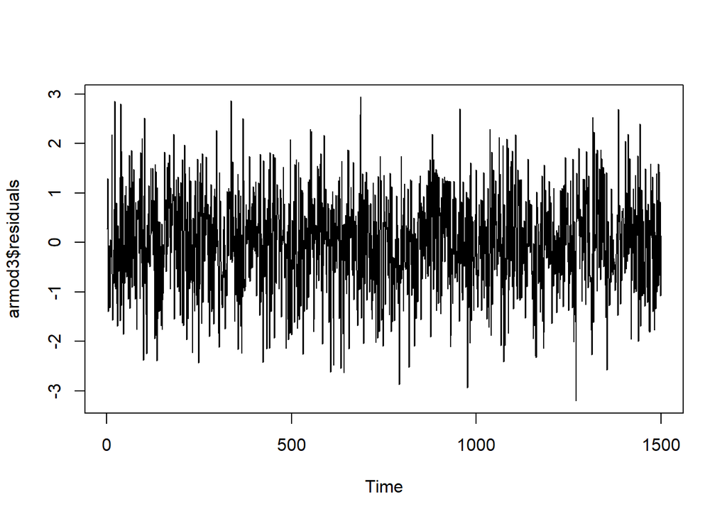

```r
plot(armod3$residuals)
```

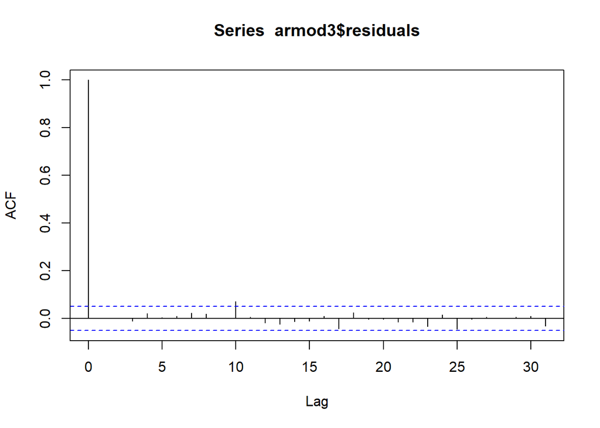

```r
acf(armod3$residuals)
```

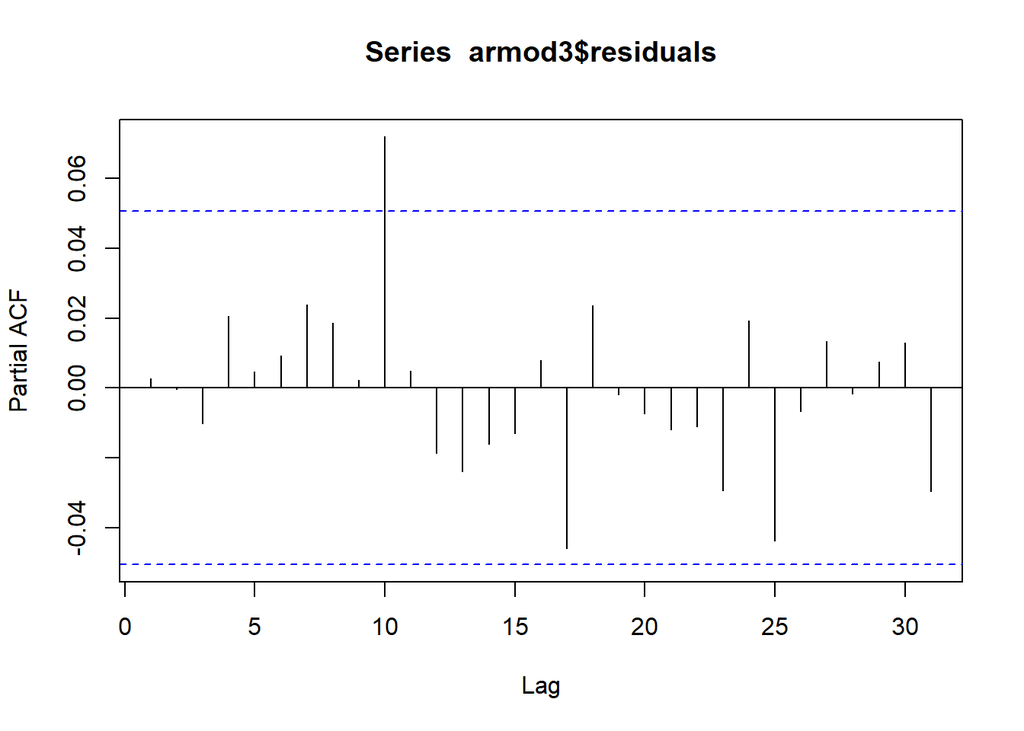

```r
pacf(armod3$residuals)
```

The above figures does indicate WN characteristics, So AR(3) is almost a perfect fit

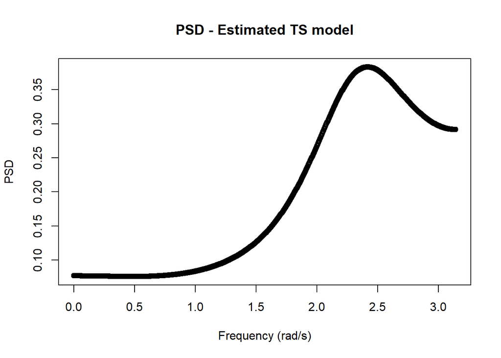

```r
#transfer function

H = function(w)1/(1 + 0.4422*exp(-1i*w) + 0.0805*exp(-2i*w) - 0.0948*exp(-3i*w))

gamma_mod = abs(sapply(w,H))^2*0.9842/(2*pi)

#actual transfer function

H_actual = function(w)(1 + 0.45*exp(-1i*w))/(1 + 0.25*exp(-2i*w))

gamma_actual = abs(sapply(w,H_actual))^2/(2*pi)

plot(w, gamma_mod, main = "PSD - Estimated TS model", xlab = "Frequency (rad/s)", ylab = "PSD")
```

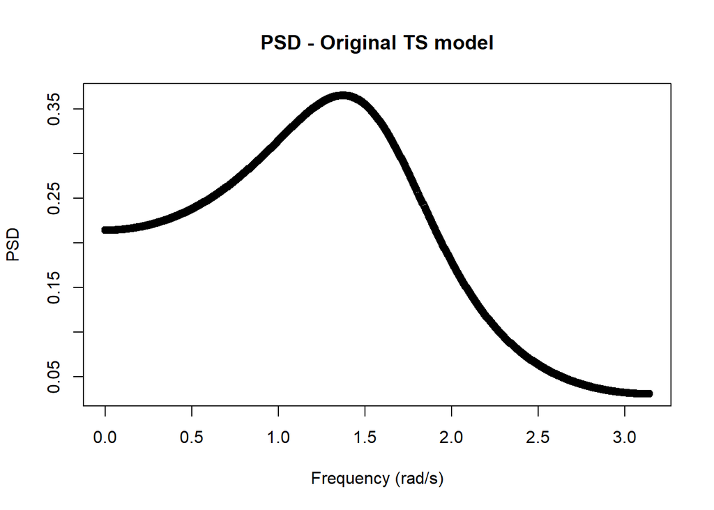

```r
plot(w, gamma_actual,main = "PSD - Original TS model", xlab = "Frequency (rad/s)", ylab = "PSD")
```

To conclude

The first method being the non-parametric approach is easier to use since we don’t have to fit any model. As we saw earlier the estimate is maximum lag sensitive and hence noisy. In the second approach we have less parameters to fit. However fitted model maybe different from the original data generating process and may result in incorrect estimates.